# Risk Factor Analysis

## Outcome Variable

**Outcome Variable:** pers_wast

## Predictor Variables

**Intervention Variable:** mage

**Adjustment Set:**

unadjusted

## Stratifying Variables

The analysis was stratified on these variable(s):

- agecat
- studyid
- country

## Data Summary

| agecat | studyid | country | mage | pers_wast | n_cell | n |
| --- | --- | --- | --- | --- | --- | --- |
| 0-24 months | ki0047075b-MAL-ED | BANGLADESH | <25 | 0 | 108 | 248 |
| 0-24 months | ki0047075b-MAL-ED | BANGLADESH | <25 | 1 | 7 | 248 |
| 0-24 months | ki0047075b-MAL-ED | BANGLADESH | [25-30) | 0 | 85 | 248 |
| 0-24 months | ki0047075b-MAL-ED | BANGLADESH | [25-30) | 1 | 4 | 248 |
| 0-24 months | ki0047075b-MAL-ED | BANGLADESH | >=30 | 0 | 42 | 248 |
| 0-24 months | ki0047075b-MAL-ED | BANGLADESH | >=30 | 1 | 2 | 248 |
| 0-24 months | ki0047075b-MAL-ED | BRAZIL | <25 | 0 | 104 | 217 |
| 0-24 months | ki0047075b-MAL-ED | BRAZIL | <25 | 1 | 0 | 217 |
| 0-24 months | ki0047075b-MAL-ED | BRAZIL | [25-30) | 0 | 63 | 217 |
| 0-24 months | ki0047075b-MAL-ED | BRAZIL | [25-30) | 1 | 1 | 217 |
| 0-24 months | ki0047075b-MAL-ED | BRAZIL | >=30 | 0 | 48 | 217 |
| 0-24 months | ki0047075b-MAL-ED | BRAZIL | >=30 | 1 | 1 | 217 |
| 0-24 months | ki0047075b-MAL-ED | INDIA | <25 | 0 | 127 | 239 |
| 0-24 months | ki0047075b-MAL-ED | INDIA | <25 | 1 | 13 | 239 |
| 0-24 months | ki0047075b-MAL-ED | INDIA | [25-30) | 0 | 70 | 239 |
| 0-24 months | ki0047075b-MAL-ED | INDIA | [25-30) | 1 | 8 | 239 |
| 0-24 months | ki0047075b-MAL-ED | INDIA | >=30 | 0 | 21 | 239 |
| 0-24 months | ki0047075b-MAL-ED | INDIA | >=30 | 1 | 0 | 239 |
| 0-24 months | ki0047075b-MAL-ED | NEPAL | <25 | 0 | 61 | 238 |
| 0-24 months | ki0047075b-MAL-ED | NEPAL | <25 | 1 | 3 | 238 |
| 0-24 months | ki0047075b-MAL-ED | NEPAL | [25-30) | 0 | 127 | 238 |
| 0-24 months | ki0047075b-MAL-ED | NEPAL | [25-30) | 1 | 1 | 238 |
| 0-24 months | ki0047075b-MAL-ED | NEPAL | >=30 | 0 | 46 | 238 |
| 0-24 months | ki0047075b-MAL-ED | NEPAL | >=30 | 1 | 0 | 238 |
| 0-24 months | ki0047075b-MAL-ED | PERU | <25 | 0 | 160 | 284 |
| 0-24 months | ki0047075b-MAL-ED | PERU | <25 | 1 | 1 | 284 |
| 0-24 months | ki0047075b-MAL-ED | PERU | [25-30) | 0 | 60 | 284 |
| 0-24 months | ki0047075b-MAL-ED | PERU | [25-30) | 1 | 0 | 284 |
| 0-24 months | ki0047075b-MAL-ED | PERU | >=30 | 0 | 63 | 284 |
| 0-24 months | ki0047075b-MAL-ED | PERU | >=30 | 1 | 0 | 284 |

[output cut: 366 more lines]

The following strata were considered:

- agecat: 0-24 months, studyid: ki0047075b-MAL-ED, country: BANGLADESH
- agecat: 0-24 months, studyid: ki0047075b-MAL-ED, country: BRAZIL
- agecat: 0-24 months, studyid: ki0047075b-MAL-ED, country: INDIA
- agecat: 0-24 months, studyid: ki0047075b-MAL-ED, country: NEPAL
- agecat: 0-24 months, studyid: ki0047075b-MAL-ED, country: PERU
- agecat: 0-24 months, studyid: ki0047075b-MAL-ED, country: SOUTH AFRICA
- agecat: 0-24 months, studyid: ki0047075b-MAL-ED, country: TANZANIA, UNITED REPUBLIC OF
- agecat: 0-24 months, studyid: ki1000108-CMC-V-BCS-2002, country: INDIA
- agecat: 0-24 months, studyid: ki1000108-IRC, country: INDIA
- agecat: 0-24 months, studyid: ki1000109-EE, country: PAKISTAN
- agecat: 0-24 months, studyid: ki1000304b-SAS-CompFeed, country: INDIA
- agecat: 0-24 months, studyid: ki1000304b-SAS-FoodSuppl, country: INDIA
- agecat: 0-24 months, studyid: ki1017093-NIH-Birth, country: BANGLADESH
- agecat: 0-24 months, studyid: ki1017093b-PROVIDE, country: BANGLADESH
- agecat: 0-24 months, studyid: ki1017093c-NIH-Crypto, country: BANGLADESH
- agecat: 0-24 months, studyid: ki1066203-TanzaniaChild2, country: TANZANIA, UNITED REPUBLIC OF
- agecat: 0-24 months, studyid: ki1101329-Keneba, country: GAMBIA
- agecat: 0-24 months, studyid: ki1112895-Guatemala BSC, country: GUATEMALA
- agecat: 0-24 months, studyid: ki1112895-iLiNS-Zinc, country: BURKINA FASO
- agecat: 0-24 months, studyid: ki1113344-GMS-Nepal, country: NEPAL
- agecat: 0-24 months, studyid: ki1119695-PROBIT, country: BELARUS
- agecat: 0-24 months, studyid: ki1126311-ZVITAMBO, country: ZIMBABWE
- agecat: 0-24 months, studyid: ki1135781-COHORTS, country: GUATEMALA
- agecat: 0-24 months, studyid: ki1135781-COHORTS, country: INDIA
- agecat: 0-24 months, studyid: ki1135781-COHORTS, country: PHILIPPINES
- agecat: 0-24 months, studyid: ki1148112-LCNI-5, country: MALAWI
- agecat: 0-24 months, studyid: kiGH5241-JiVitA-3, country: BANGLADESH
- agecat: 0-6 months, studyid: ki0047075b-MAL-ED, country: BANGLADESH
- agecat: 0-6 months, studyid: ki0047075b-MAL-ED, country: BRAZIL
- agecat: 0-6 months, studyid: ki0047075b-MAL-ED, country: INDIA
- agecat: 0-6 months, studyid: ki0047075b-MAL-ED, country: NEPAL
- agecat: 0-6 months, studyid: ki0047075b-MAL-ED, country: PERU
- agecat: 0-6 months, studyid: ki0047075b-MAL-ED, country: SOUTH AFRICA
- agecat: 0-6 months, studyid: ki0047075b-MAL-ED, country: TANZANIA, UNITED REPUBLIC OF
- agecat: 0-6 months, studyid: ki1000108-CMC-V-BCS-2002, country: INDIA
- agecat: 0-6 months, studyid: ki1000108-IRC, country: INDIA
- agecat: 0-6 months, studyid: ki1000109-EE, country: PAKISTAN
- agecat: 0-6 months, studyid: ki1017093b-PROVIDE, country: BANGLADESH
- agecat: 0-6 months, studyid: ki1066203-TanzaniaChild2, country: TANZANIA, UNITED REPUBLIC OF
- agecat: 0-6 months, studyid: ki1101329-Keneba, country: GAMBIA
- agecat: 0-6 months, studyid: ki1113344-GMS-Nepal, country: NEPAL
- agecat: 6-24 months, studyid: ki0047075b-MAL-ED, country: BANGLADESH
- agecat: 6-24 months, studyid: ki0047075b-MAL-ED, country: BRAZIL
- agecat: 6-24 months, studyid: ki0047075b-MAL-ED, country: INDIA
- agecat: 6-24 months, studyid: ki0047075b-MAL-ED, country: NEPAL
- agecat: 6-24 months, studyid: ki0047075b-MAL-ED, country: PERU
- agecat: 6-24 months, studyid: ki0047075b-MAL-ED, country: SOUTH AFRICA
- agecat: 6-24 months, studyid: ki0047075b-MAL-ED, country: TANZANIA, UNITED REPUBLIC OF
- agecat: 6-24 months, studyid: ki1000108-CMC-V-BCS-2002, country: INDIA
- agecat: 6-24 months, studyid: ki1000108-IRC, country: INDIA
- agecat: 6-24 months, studyid: ki1000109-EE, country: PAKISTAN
- agecat: 6-24 months, studyid: ki1000304b-SAS-CompFeed, country: INDIA
- agecat: 6-24 months, studyid: ki1000304b-SAS-FoodSuppl, country: INDIA
- agecat: 6-24 months, studyid: ki1017093-NIH-Birth, country: BANGLADESH
- agecat: 6-24 months, studyid: ki1017093b-PROVIDE, country: BANGLADESH
- agecat: 6-24 months, studyid: ki1017093c-NIH-Crypto, country: BANGLADESH
- agecat: 6-24 months, studyid: ki1066203-TanzaniaChild2, country: TANZANIA, UNITED REPUBLIC OF
- agecat: 6-24 months, studyid: ki1101329-Keneba, country: GAMBIA
- agecat: 6-24 months, studyid: ki1112895-Guatemala BSC, country: GUATEMALA
- agecat: 6-24 months, studyid: ki1112895-iLiNS-Zinc, country: BURKINA FASO
- agecat: 6-24 months, studyid: ki1113344-GMS-Nepal, country: NEPAL
- agecat: 6-24 months, studyid: ki1119695-PROBIT, country: BELARUS
- agecat: 6-24 months, studyid: ki1126311-ZVITAMBO, country: ZIMBABWE
- agecat: 6-24 months, studyid: ki1135781-COHORTS, country: GUATEMALA
- agecat: 6-24 months, studyid: ki1135781-COHORTS, country: PHILIPPINES
- agecat: 6-24 months, studyid: ki1148112-LCNI-5, country: MALAWI

### Dropped Strata

Some strata were dropped due to rare outcomes:

- agecat: 0-24 months, studyid: ki0047075b-MAL-ED, country: BANGLADESH
- agecat: 0-24 months, studyid: ki0047075b-MAL-ED, country: BRAZIL
- agecat: 0-24 months, studyid: ki0047075b-MAL-ED, country: INDIA
- agecat: 0-24 months, studyid: ki0047075b-MAL-ED, country: NEPAL
- agecat: 0-24 months, studyid: ki0047075b-MAL-ED, country: PERU
- agecat: 0-24 months, studyid: ki0047075b-MAL-ED, country: SOUTH AFRICA
- agecat: 0-24 months, studyid: ki0047075b-MAL-ED, country: TANZANIA, UNITED REPUBLIC OF
- agecat: 0-24 months, studyid: ki1000108-CMC-V-BCS-2002, country: INDIA
- agecat: 0-24 months, studyid: ki1000109-EE, country: PAKISTAN
- agecat: 0-24 months, studyid: ki1112895-Guatemala BSC, country: GUATEMALA
- agecat: 0-24 months, studyid: ki1148112-LCNI-5, country: MALAWI
- agecat: 0-6 months, studyid: ki0047075b-MAL-ED, country: BANGLADESH
- agecat: 0-6 months, studyid: ki0047075b-MAL-ED, country: BRAZIL
- agecat: 0-6 months, studyid: ki0047075b-MAL-ED, country: INDIA
- agecat: 0-6 months, studyid: ki0047075b-MAL-ED, country: NEPAL
- agecat: 0-6 months, studyid: ki0047075b-MAL-ED, country: PERU
- agecat: 0-6 months, studyid: ki0047075b-MAL-ED, country: SOUTH AFRICA
- agecat: 0-6 months, studyid: ki0047075b-MAL-ED, country: TANZANIA, UNITED REPUBLIC OF
- agecat: 0-6 months, studyid: ki1000108-CMC-V-BCS-2002, country: INDIA
- agecat: 0-6 months, studyid: ki1000109-EE, country: PAKISTAN
- agecat: 0-6 months, studyid: ki1017093b-PROVIDE, country: BANGLADESH
- agecat: 6-24 months, studyid: ki0047075b-MAL-ED, country: BANGLADESH
- agecat: 6-24 months, studyid: ki0047075b-MAL-ED, country: BRAZIL
- agecat: 6-24 months, studyid: ki0047075b-MAL-ED, country: INDIA
- agecat: 6-24 months, studyid: ki0047075b-MAL-ED, country: NEPAL
- agecat: 6-24 months, studyid: ki0047075b-MAL-ED, country: PERU
- agecat: 6-24 months, studyid: ki0047075b-MAL-ED, country: SOUTH AFRICA
- agecat: 6-24 months, studyid: ki0047075b-MAL-ED, country: TANZANIA, UNITED REPUBLIC OF
- agecat: 6-24 months, studyid: ki1000108-CMC-V-BCS-2002, country: INDIA
- agecat: 6-24 months, studyid: ki1000109-EE, country: PAKISTAN
- agecat: 6-24 months, studyid: ki1112895-Guatemala BSC, country: GUATEMALA
- agecat: 6-24 months, studyid: ki1119695-PROBIT, country: BELARUS
- agecat: 6-24 months, studyid: ki1148112-LCNI-5, country: MALAWI

## Methods Detail

We’re interested in the causal parameters $E[Y_a]$ for all values of $a \in \mathcal{A}$. These parameters represent the mean outcome if, possibly contrary to fact, we intervened to set all units to have $A=a$. Under the randomization and positivity assumptions, these are identified by the statistical parameters $\psi_a=E_W[E_{Y|A,W}(Y|A=a,W)]$. In addition, we’re interested in the mean of $Y$, $E[Y]$ under no intervention (the observed mean). We will estimate these parameters by using SuperLearner to fit the relevant likelihood factors – $E_{Y|A,W}(Y|A=a,W)$ and $p(A=a|W)$, and then updating our likelihood fit using a joint TMLE.

For unadjusted analyses ($W=\{\}$), initial likelihoods were estimated using Lrnr_glm to estimate the simple $E(Y|A)$ and Lrnr_mean to estimate $p(A)$. For adjusted analyses, a small library containing Lrnr_glmnet, Lrnr_xgboost, and Lrnr_mean was used.

Having estimated these parameters, we will then use the delta method to estimate relative risks and attributable risks relative to a prespecified baseline level of $A$.

# Results Detail

## Results Plots

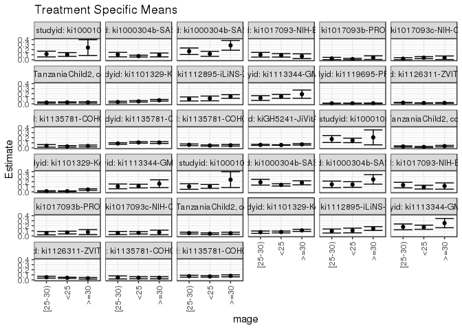

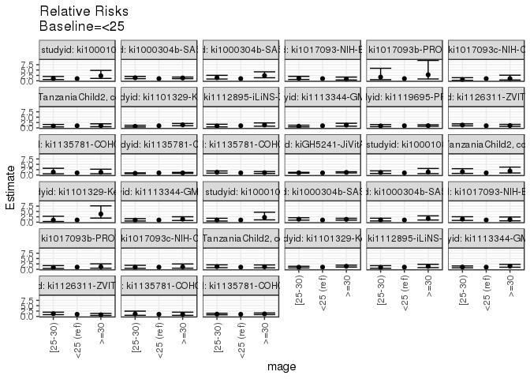

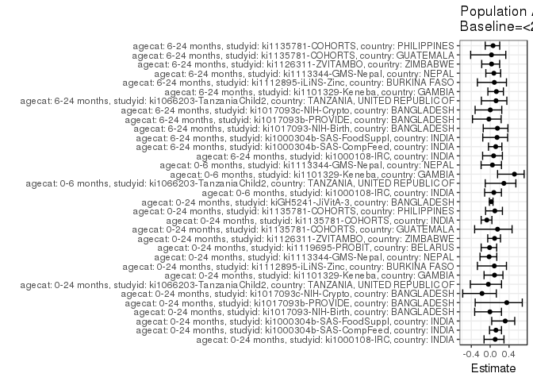

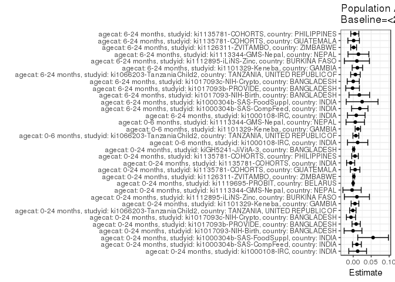

## Results Table

### Parameter: TSM

| agecat | studyid | country | intervention_level | baseline_level | estimate | ci_lower | ci_upper |
| --- | --- | --- | --- | --- | --- | --- | --- |
| 0-24 months | ki1000108-IRC | INDIA | <25 | NA | 0.1046512 | 0.0672542 | 0.1420482 |
| 0-24 months | ki1000108-IRC | INDIA | [25-30) | NA | 0.1138211 | 0.0576261 | 0.1700162 |
| 0-24 months | ki1000108-IRC | INDIA | >=30 | NA | 0.2413793 | 0.0854450 | 0.3973136 |
| 0-24 months | ki1000304b-SAS-CompFeed | INDIA | <25 | NA | 0.0732558 | 0.0559831 | 0.0905286 |
| 0-24 months | ki1000304b-SAS-CompFeed | INDIA | [25-30) | NA | 0.1027778 | 0.0583426 | 0.1472130 |
| 0-24 months | ki1000304b-SAS-CompFeed | INDIA | >=30 | NA | 0.0958904 | 0.0577106 | 0.1340702 |
| 0-24 months | ki1000304b-SAS-FoodSuppl | INDIA | <25 | NA | 0.1180124 | 0.0681113 | 0.1679135 |
| 0-24 months | ki1000304b-SAS-FoodSuppl | INDIA | [25-30) | NA | 0.1692308 | 0.1046897 | 0.2337718 |
| 0-24 months | ki1000304b-SAS-FoodSuppl | INDIA | >=30 | NA | 0.2857143 | 0.1889778 | 0.3824508 |
| 0-24 months | ki1017093-NIH-Birth | BANGLADESH | <25 | NA | 0.0888031 | 0.0541273 | 0.1234789 |
| 0-24 months | ki1017093-NIH-Birth | BANGLADESH | [25-30) | NA | 0.1000000 | 0.0534716 | 0.1465284 |
| 0-24 months | ki1017093-NIH-Birth | BANGLADESH | >=30 | NA | 0.0707965 | 0.0234619 | 0.1181311 |
| 0-24 months | ki1017093b-PROVIDE | BANGLADESH | <25 | NA | 0.0151976 | 0.0019678 | 0.0284273 |
| 0-24 months | ki1017093b-PROVIDE | BANGLADESH | [25-30) | NA | 0.0259067 | 0.0034774 | 0.0483360 |
| 0-24 months | ki1017093b-PROVIDE | BANGLADESH | >=30 | NA | 0.0423729 | 0.0059991 | 0.0787467 |
| 0-24 months | ki1017093c-NIH-Crypto | BANGLADESH | <25 | NA | 0.0417755 | 0.0217242 | 0.0618267 |
| 0-24 months | ki1017093c-NIH-Crypto | BANGLADESH | [25-30) | NA | 0.0223214 | 0.0029625 | 0.0416803 |
| 0-24 months | ki1017093c-NIH-Crypto | BANGLADESH | >=30 | NA | 0.0406504 | 0.0057272 | 0.0755736 |
| 0-24 months | ki1066203-TanzaniaChild2 | TANZANIA, UNITED REPUBLIC OF | <25 | NA | 0.0280488 | 0.0167451 | 0.0393525 |
| 0-24 months | ki1066203-TanzaniaChild2 | TANZANIA, UNITED REPUBLIC OF | [25-30) | NA | 0.0244233 | 0.0132766 | 0.0355701 |
| 0-24 months | ki1066203-TanzaniaChild2 | TANZANIA, UNITED REPUBLIC OF | >=30 | NA | 0.0287648 | 0.0152861 | 0.0422435 |
| 0-24 months | ki1101329-Keneba | GAMBIA | <25 | NA | 0.0487805 | 0.0353187 | 0.0622423 |
| 0-24 months | ki1101329-Keneba | GAMBIA | [25-30) | NA | 0.0358491 | 0.0200179 | 0.0516802 |
| 0-24 months | ki1101329-Keneba | GAMBIA | >=30 | NA | 0.0696133 | 0.0530292 | 0.0861973 |
| 0-24 months | ki1112895-iLiNS-Zinc | BURKINA FASO | <25 | NA | 0.1066667 | 0.0597076 | 0.1536257 |
| 0-24 months | ki1112895-iLiNS-Zinc | BURKINA FASO | [25-30) | NA | 0.0958231 | 0.0559194 | 0.1357268 |
| 0-24 months | ki1112895-iLiNS-Zinc | BURKINA FASO | >=30 | NA | 0.1451906 | 0.1082806 | 0.1821006 |
| 0-24 months | ki1113344-GMS-Nepal | NEPAL | <25 | NA | 0.1467890 | 0.1083992 | 0.1851788 |
| 0-24 months | ki1113344-GMS-Nepal | NEPAL | [25-30) | NA | 0.1136364 | 0.0667093 | 0.1605634 |
| 0-24 months | ki1113344-GMS-Nepal | NEPAL | >=30 | NA | 0.1910112 | 0.1092738 | 0.2727487 |

[output cut: 69 more lines]

### Parameter: E(Y)

| agecat | studyid | country | intervention_level | baseline_level | estimate | ci_lower | ci_upper |
| --- | --- | --- | --- | --- | --- | --- | --- |
| 0-24 months | ki1000108-IRC | INDIA | NA | NA | 0.1170732 | 0.0859146 | 0.1482317 |
| 0-24 months | ki1000304b-SAS-CompFeed | INDIA | NA | NA | 0.0834553 | 0.0601989 | 0.1067118 |
| 0-24 months | ki1000304b-SAS-FoodSuppl | INDIA | NA | NA | 0.1733333 | 0.1349698 | 0.2116969 |
| 0-24 months | ki1017093-NIH-Birth | BANGLADESH | NA | NA | 0.0883459 | 0.0642074 | 0.1124843 |
| 0-24 months | ki1017093b-PROVIDE | BANGLADESH | NA | NA | 0.0234375 | 0.0117074 | 0.0351676 |
| 0-24 months | ki1017093c-NIH-Crypto | BANGLADESH | NA | NA | 0.0356164 | 0.0221630 | 0.0490699 |
| 0-24 months | ki1066203-TanzaniaChild2 | TANZANIA, UNITED REPUBLIC OF | NA | NA | 0.0270019 | 0.0201456 | 0.0338581 |
| 0-24 months | ki1101329-Keneba | GAMBIA | NA | NA | 0.0537412 | 0.0447529 | 0.0627295 |
| 0-24 months | ki1112895-iLiNS-Zinc | BURKINA FASO | NA | NA | 0.1169626 | 0.0922087 | 0.1417166 |
| 0-24 months | ki1113344-GMS-Nepal | NEPAL | NA | NA | 0.1435811 | 0.1153098 | 0.1718524 |
| 0-24 months | ki1119695-PROBIT | BELARUS | NA | NA | 0.0095893 | 0.0052864 | 0.0138922 |
| 0-24 months | ki1126311-ZVITAMBO | ZIMBABWE | NA | NA | 0.0178284 | 0.0151404 | 0.0205163 |
| 0-24 months | ki1135781-COHORTS | GUATEMALA | NA | NA | 0.0341880 | 0.0232075 | 0.0451686 |
| 0-24 months | ki1135781-COHORTS | INDIA | NA | NA | 0.0995575 | 0.0903557 | 0.1087594 |
| 0-24 months | ki1135781-COHORTS | PHILIPPINES | NA | NA | 0.0512273 | 0.0430760 | 0.0593786 |
| 0-24 months | kiGH5241-JiVitA-3 | BANGLADESH | NA | NA | 0.0572322 | 0.0531458 | 0.0613186 |
| 0-6 months | ki1000108-IRC | INDIA | NA | NA | 0.1592040 | 0.1233945 | 0.1950135 |
| 0-6 months | ki1066203-TanzaniaChild2 | TANZANIA, UNITED REPUBLIC OF | NA | NA | 0.0254403 | 0.0186125 | 0.0322681 |
| 0-6 months | ki1101329-Keneba | GAMBIA | NA | NA | 0.0251108 | 0.0183045 | 0.0319170 |
| 0-6 months | ki1113344-GMS-Nepal | NEPAL | NA | NA | 0.1199262 | 0.0925504 | 0.1473020 |
| 6-24 months | ki1000108-IRC | INDIA | NA | NA | 0.1170732 | 0.0859146 | 0.1482317 |
| 6-24 months | ki1000304b-SAS-CompFeed | INDIA | NA | NA | 0.1561462 | 0.1410608 | 0.1712315 |
| 6-24 months | ki1000304b-SAS-FoodSuppl | INDIA | NA | NA | 0.1695402 | 0.1300601 | 0.2090204 |
| 6-24 months | ki1017093-NIH-Birth | BANGLADESH | NA | NA | 0.1102041 | 0.0824493 | 0.1379589 |
| 6-24 months | ki1017093b-PROVIDE | BANGLADESH | NA | NA | 0.0632280 | 0.0437545 | 0.0827015 |
| 6-24 months | ki1017093c-NIH-Crypto | BANGLADESH | NA | NA | 0.0602582 | 0.0425793 | 0.0779372 |
| 6-24 months | ki1066203-TanzaniaChild2 | TANZANIA, UNITED REPUBLIC OF | NA | NA | 0.0496454 | 0.0392926 | 0.0599982 |
| 6-24 months | ki1101329-Keneba | GAMBIA | NA | NA | 0.0883679 | 0.0765532 | 0.1001826 |
| 6-24 months | ki1112895-iLiNS-Zinc | BURKINA FASO | NA | NA | 0.1169626 | 0.0922087 | 0.1417166 |
| 6-24 months | ki1113344-GMS-Nepal | NEPAL | NA | NA | 0.1854419 | 0.1537023 | 0.2171816 |
| 6-24 months | ki1126311-ZVITAMBO | ZIMBABWE | NA | NA | 0.0427543 | 0.0343408 | 0.0511677 |
| 6-24 months | ki1135781-COHORTS | GUATEMALA | NA | NA | 0.0439914 | 0.0308183 | 0.0571645 |
| 6-24 months | ki1135781-COHORTS | PHILIPPINES | NA | NA | 0.0731338 | 0.0631985 | 0.0830690 |

### Parameter: RR

| agecat | studyid | country | intervention_level | baseline_level | estimate | ci_lower | ci_upper |
| --- | --- | --- | --- | --- | --- | --- | --- |
| 0-24 months | ki1000108-IRC | INDIA | <25 | <25 | 1.0000000 | 1.0000000 | 1.000000 |
| 0-24 months | ki1000108-IRC | INDIA | [25-30) | <25 | 1.0876242 | 0.5912760 | 2.000633 |
| 0-24 months | ki1000108-IRC | INDIA | >=30 | <25 | 2.3065134 | 1.1023830 | 4.825913 |
| 0-24 months | ki1000304b-SAS-CompFeed | INDIA | <25 | <25 | 1.0000000 | 1.0000000 | 1.000000 |
| 0-24 months | ki1000304b-SAS-CompFeed | INDIA | [25-30) | <25 | 1.4029982 | 0.9760342 | 2.016737 |
| 0-24 months | ki1000304b-SAS-CompFeed | INDIA | >=30 | <25 | 1.3089802 | 0.9863043 | 1.737222 |
| 0-24 months | ki1000304b-SAS-FoodSuppl | INDIA | <25 | <25 | 1.0000000 | 1.0000000 | 1.000000 |
| 0-24 months | ki1000304b-SAS-FoodSuppl | INDIA | [25-30) | <25 | 1.4340081 | 0.8114317 | 2.534260 |
| 0-24 months | ki1000304b-SAS-FoodSuppl | INDIA | >=30 | <25 | 2.4210526 | 1.4084745 | 4.161592 |
| 0-24 months | ki1017093-NIH-Birth | BANGLADESH | <25 | <25 | 1.0000000 | 1.0000000 | 1.000000 |
| 0-24 months | ki1017093-NIH-Birth | BANGLADESH | [25-30) | <25 | 1.1260870 | 0.6134386 | 2.067153 |
| 0-24 months | ki1017093-NIH-Birth | BANGLADESH | >=30 | <25 | 0.7972297 | 0.3675530 | 1.729207 |
| 0-24 months | ki1017093b-PROVIDE | BANGLADESH | <25 | <25 | 1.0000000 | 1.0000000 | 1.000000 |
| 0-24 months | ki1017093b-PROVIDE | BANGLADESH | [25-30) | <25 | 1.7046632 | 0.4993851 | 5.818910 |
| 0-24 months | ki1017093b-PROVIDE | BANGLADESH | >=30 | <25 | 2.7881356 | 0.8210254 | 9.468282 |
| 0-24 months | ki1017093c-NIH-Crypto | BANGLADESH | <25 | <25 | 1.0000000 | 1.0000000 | 1.000000 |
| 0-24 months | ki1017093c-NIH-Crypto | BANGLADESH | [25-30) | <25 | 0.5343192 | 0.1982952 | 1.439757 |
| 0-24 months | ki1017093c-NIH-Crypto | BANGLADESH | >=30 | <25 | 0.9730691 | 0.3637102 | 2.603346 |
| 0-24 months | ki1066203-TanzaniaChild2 | TANZANIA, UNITED REPUBLIC OF | <25 | <25 | 1.0000000 | 1.0000000 | 1.000000 |
| 0-24 months | ki1066203-TanzaniaChild2 | TANZANIA, UNITED REPUBLIC OF | [25-30) | <25 | 0.8707451 | 0.4736600 | 1.600720 |
| 0-24 months | ki1066203-TanzaniaChild2 | TANZANIA, UNITED REPUBLIC OF | >=30 | <25 | 1.0255278 | 0.5527558 | 1.902662 |
| 0-24 months | ki1101329-Keneba | GAMBIA | <25 | <25 | 1.0000000 | 1.0000000 | 1.000000 |
| 0-24 months | ki1101329-Keneba | GAMBIA | [25-30) | <25 | 0.7349057 | 0.4365923 | 1.237050 |
| 0-24 months | ki1101329-Keneba | GAMBIA | >=30 | <25 | 1.4270718 | 0.9910933 | 2.054836 |
| 0-24 months | ki1112895-iLiNS-Zinc | BURKINA FASO | <25 | <25 | 1.0000000 | 1.0000000 | 1.000000 |
| 0-24 months | ki1112895-iLiNS-Zinc | BURKINA FASO | [25-30) | <25 | 0.8983416 | 0.4759908 | 1.695448 |
| 0-24 months | ki1112895-iLiNS-Zinc | BURKINA FASO | >=30 | <25 | 1.3611615 | 0.7972012 | 2.324082 |
| 0-24 months | ki1113344-GMS-Nepal | NEPAL | <25 | <25 | 1.0000000 | 1.0000000 | 1.000000 |
| 0-24 months | ki1113344-GMS-Nepal | NEPAL | [25-30) | <25 | 0.7741477 | 0.4748292 | 1.262148 |
| 0-24 months | ki1113344-GMS-Nepal | NEPAL | >=30 | <25 | 1.3012640 | 0.7880648 | 2.148666 |

[output cut: 69 more lines]

### Parameter: PAR

| agecat | studyid | country | intervention_level | baseline_level | estimate | ci_lower | ci_upper |
| --- | --- | --- | --- | --- | --- | --- | --- |
| 0-24 months | ki1000108-IRC | INDIA | <25 | NA | 0.0124220 | -0.0122617 | 0.0371057 |
| 0-24 months | ki1000304b-SAS-CompFeed | INDIA | <25 | NA | 0.0101995 | -0.0021050 | 0.0225041 |
| 0-24 months | ki1000304b-SAS-FoodSuppl | INDIA | <25 | NA | 0.0553209 | 0.0126161 | 0.0980257 |
| 0-24 months | ki1017093-NIH-Birth | BANGLADESH | <25 | NA | -0.0004572 | -0.0252424 | 0.0243280 |
| 0-24 months | ki1017093b-PROVIDE | BANGLADESH | <25 | NA | 0.0082399 | -0.0032785 | 0.0197583 |
| 0-24 months | ki1017093c-NIH-Crypto | BANGLADESH | <25 | NA | -0.0061590 | -0.0188542 | 0.0065362 |
| 0-24 months | ki1066203-TanzaniaChild2 | TANZANIA, UNITED REPUBLIC OF | <25 | NA | -0.0010469 | -0.0098348 | 0.0077409 |
| 0-24 months | ki1101329-Keneba | GAMBIA | <25 | NA | 0.0049607 | -0.0057433 | 0.0156648 |
| 0-24 months | ki1112895-iLiNS-Zinc | BURKINA FASO | <25 | NA | 0.0102960 | -0.0245383 | 0.0451302 |
| 0-24 months | ki1113344-GMS-Nepal | NEPAL | <25 | NA | -0.0032079 | -0.0286032 | 0.0221873 |
| 0-24 months | ki1119695-PROBIT | BELARUS | <25 | NA | -0.0001260 | -0.0017030 | 0.0014511 |
| 0-24 months | ki1126311-ZVITAMBO | ZIMBABWE | <25 | NA | 0.0016714 | -0.0007480 | 0.0040909 |
| 0-24 months | ki1135781-COHORTS | GUATEMALA | <25 | NA | 0.0053419 | -0.0078837 | 0.0185675 |
| 0-24 months | ki1135781-COHORTS | INDIA | <25 | NA | -0.0070848 | -0.0183886 | 0.0042190 |
| 0-24 months | ki1135781-COHORTS | PHILIPPINES | <25 | NA | 0.0050735 | -0.0040403 | 0.0141873 |
| 0-24 months | kiGH5241-JiVitA-3 | BANGLADESH | <25 | NA | 0.0012835 | -0.0009124 | 0.0034793 |
| 0-6 months | ki1000108-IRC | INDIA | <25 | NA | 0.0123786 | -0.0158454 | 0.0406026 |
| 0-6 months | ki1066203-TanzaniaChild2 | TANZANIA, UNITED REPUBLIC OF | <25 | NA | 0.0073991 | -0.0008313 | 0.0156294 |
| 0-6 months | ki1101329-Keneba | GAMBIA | <25 | NA | 0.0129157 | 0.0053529 | 0.0204784 |
| 0-6 months | ki1113344-GMS-Nepal | NEPAL | <25 | NA | 0.0057393 | -0.0199504 | 0.0314291 |
| 6-24 months | ki1000108-IRC | INDIA | <25 | NA | 0.0085460 | -0.0158981 | 0.0329902 |
| 6-24 months | ki1000304b-SAS-CompFeed | INDIA | <25 | NA | 0.0183509 | -0.0043998 | 0.0411016 |
| 6-24 months | ki1000304b-SAS-FoodSuppl | INDIA | <25 | NA | 0.0248034 | -0.0194163 | 0.0690230 |
| 6-24 months | ki1017093-NIH-Birth | BANGLADESH | <25 | NA | 0.0169837 | -0.0116689 | 0.0456364 |
| 6-24 months | ki1017093b-PROVIDE | BANGLADESH | <25 | NA | -0.0017071 | -0.0206883 | 0.0172741 |
| 6-24 months | ki1017093c-NIH-Crypto | BANGLADESH | <25 | NA | 0.0001490 | -0.0166655 | 0.0169634 |
| 6-24 months | ki1066203-TanzaniaChild2 | TANZANIA, UNITED REPUBLIC OF | <25 | NA | 0.0061671 | -0.0070858 | 0.0194201 |
| 6-24 months | ki1101329-Keneba | GAMBIA | <25 | NA | 0.0116237 | -0.0028911 | 0.0261385 |
| 6-24 months | ki1112895-iLiNS-Zinc | BURKINA FASO | <25 | NA | 0.0102960 | -0.0245383 | 0.0451302 |
| 6-24 months | ki1113344-GMS-Nepal | NEPAL | <25 | NA | 0.0145559 | -0.0144776 | 0.0435893 |
| 6-24 months | ki1126311-ZVITAMBO | ZIMBABWE | <25 | NA | 0.0012677 | -0.0068143 | 0.0093496 |
| 6-24 months | ki1135781-COHORTS | GUATEMALA | <25 | NA | 0.0012107 | -0.0148099 | 0.0172313 |
| 6-24 months | ki1135781-COHORTS | PHILIPPINES | <25 | NA | 0.0044978 | -0.0067256 | 0.0157212 |

### Parameter: PAF

| agecat | studyid | country | intervention_level | baseline_level | estimate | ci_lower | ci_upper |
| --- | --- | --- | --- | --- | --- | --- | --- |
| 0-24 months | ki1000108-IRC | INDIA | <25 | NA | 0.1061046 | -0.1298445 | 0.2927797 |
| 0-24 months | ki1000304b-SAS-CompFeed | INDIA | <25 | NA | 0.1222154 | -0.0137786 | 0.2399664 |
| 0-24 months | ki1000304b-SAS-FoodSuppl | INDIA | <25 | NA | 0.3191591 | 0.0327978 | 0.5207369 |
| 0-24 months | ki1017093-NIH-Birth | BANGLADESH | <25 | NA | -0.0051754 | -0.3287812 | 0.2396208 |
| 0-24 months | ki1017093b-PROVIDE | BANGLADESH | <25 | NA | 0.3515704 | -0.3179584 | 0.6809756 |
| 0-24 months | ki1017093c-NIH-Crypto | BANGLADESH | <25 | NA | -0.1729263 | -0.5820110 | 0.1303752 |
| 0-24 months | ki1066203-TanzaniaChild2 | TANZANIA, UNITED REPUBLIC OF | <25 | NA | -0.0387721 | -0.4207858 | 0.2405277 |
| 0-24 months | ki1101329-Keneba | GAMBIA | <25 | NA | 0.0923077 | -0.1297443 | 0.2707152 |
| 0-24 months | ki1112895-iLiNS-Zinc | BURKINA FASO | <25 | NA | 0.0880279 | -0.2706307 | 0.3454486 |
| 0-24 months | ki1113344-GMS-Nepal | NEPAL | <25 | NA | -0.0223421 | -0.2153915 | 0.1400438 |
| 0-24 months | ki1119695-PROBIT | BELARUS | <25 | NA | -0.0131349 | -0.1911873 | 0.1383032 |
| 0-24 months | ki1126311-ZVITAMBO | ZIMBABWE | <25 | NA | 0.0937507 | -0.0518169 | 0.2191722 |
| 0-24 months | ki1135781-COHORTS | GUATEMALA | <25 | NA | 0.1562500 | -0.3296912 | 0.4646019 |
| 0-24 months | ki1135781-COHORTS | INDIA | <25 | NA | -0.0711626 | -0.1907770 | 0.0364365 |
| 0-24 months | ki1135781-COHORTS | PHILIPPINES | <25 | NA | 0.0990385 | -0.0968825 | 0.2599648 |
| 0-24 months | kiGH5241-JiVitA-3 | BANGLADESH | <25 | NA | 0.0224257 | -0.0167318 | 0.0600750 |
| 0-6 months | ki1000108-IRC | INDIA | <25 | NA | 0.0777530 | -0.1170336 | 0.2385730 |
| 0-6 months | ki1066203-TanzaniaChild2 | TANZANIA, UNITED REPUBLIC OF | <25 | NA | 0.2908406 | -0.1046728 | 0.5447457 |
| 0-6 months | ki1101329-Keneba | GAMBIA | <25 | NA | 0.5143472 | 0.1569148 | 0.7202434 |
| 0-6 months | ki1113344-GMS-Nepal | NEPAL | <25 | NA | 0.0478573 | -0.1921079 | 0.2395188 |
| 6-24 months | ki1000108-IRC | INDIA | <25 | NA | 0.0729974 | -0.1603245 | 0.2594022 |
| 6-24 months | ki1000304b-SAS-CompFeed | INDIA | <25 | NA | 0.1175239 | -0.0361478 | 0.2484044 |
| 6-24 months | ki1000304b-SAS-FoodSuppl | INDIA | <25 | NA | 0.1462979 | -0.1567820 | 0.3699701 |
| 6-24 months | ki1017093-NIH-Birth | BANGLADESH | <25 | NA | 0.1541117 | -0.1471467 | 0.3762550 |
| 6-24 months | ki1017093b-PROVIDE | BANGLADESH | <25 | NA | -0.0269993 | -0.3755514 | 0.2332328 |
| 6-24 months | ki1017093c-NIH-Crypto | BANGLADESH | <25 | NA | 0.0024720 | -0.3195032 | 0.2458813 |
| 6-24 months | ki1066203-TanzaniaChild2 | TANZANIA, UNITED REPUBLIC OF | <25 | NA | 0.1242236 | -0.1863334 | 0.3534833 |
| 6-24 months | ki1101329-Keneba | GAMBIA | <25 | NA | 0.1315377 | -0.0483293 | 0.2805441 |
| 6-24 months | ki1112895-iLiNS-Zinc | BURKINA FASO | <25 | NA | 0.0880279 | -0.2706307 | 0.3454486 |
| 6-24 months | ki1113344-GMS-Nepal | NEPAL | <25 | NA | 0.0784928 | -0.0917601 | 0.2221960 |
| 6-24 months | ki1126311-ZVITAMBO | ZIMBABWE | <25 | NA | 0.0296502 | -0.1789505 | 0.2013416 |
| 6-24 months | ki1135781-COHORTS | GUATEMALA | <25 | NA | 0.0275205 | -0.4140924 | 0.3312203 |
| 6-24 months | ki1135781-COHORTS | PHILIPPINES | <25 | NA | 0.0615009 | -0.1049943 | 0.2029095 |